# Prediction Assignment Writeup: Correct Weight Lifting Exercises

Miguel Angel Huerta

2 de septiembre de 2018

# Introduction

Using devices such as Jawbone Up, Nike FuelBand, and Fitbit it is now possible to collect a large amount of data about personal activity relatively inexpensively. These type of devices are part of the quantified self movement - a group of enthusiasts who take measurements about themselves regularly to improve their health, to find patterns in their behavior, or because they are tech geeks. One thing that people regularly do is quantify how much of a particular activity they do, but they rarely quantify how well they do it. In this project, your will make use of data from accelerometers on the belt, forearm, arm, and dumbell of 6 participants. GThese six young health participants were asked to perform one set of 10 repetitions of the Unilateral Dumbbell Biceps Curl in five different fashions: exactly according to the specification (Class A), throwing the elbows to the front (Class B), lifting the dumbbell only halfway (Class C), lowering the dumbbell only halfway (Class D) and throwing the hips to the front (Class E). Class A corresponds to the specified execution of the exercise, while the other 4 classes correspond to common mistakes.

More information http://web.archive.org/web/20161224072740/http:/groupware.les.inf.puc-rio.br/har (see the section on the Weight Lifting Exercise Dataset).

# Goal

The goal of your project is to predict the manner in which they did the exercise. This is the “classe” variable in the training set. You may use any of the other variables to predict with. You should create a report describing how you built your model, how you used cross validation, what you think the expected out of sample error is, and why you made the choices you did. You will also use your prediction model to predict 20 different test cases.

## DATA CLEANING

```r
testData <- read.csv(testFile)
trainingData <- read.csv(trainingFile)
# remove variables with Nearly Zero Variance
NZV <- nearZeroVar(trainingData)
TrainSet <- trainingData[, -NZV]
TestSet  <- testData[, -NZV]
dim(TestSet)
```

```
## [1]  20 100
```

```r
# remove variables that are mostly NA
AllNA    <- sapply(TrainSet, function(x) mean(is.na(x))) > 0.95
TrainSet <- TrainSet[, AllNA==FALSE]
TestSet  <- TestSet[, AllNA==FALSE]
dim(TestSet)
```

```
## [1] 20 59
```

```r
# remove identification only variables (columns 1 to 6)
TrainSet <- TrainSet[, -(1:6)]
TestSet  <- TestSet[, -(1:6)]
dim(TrainSet)
```

```
## [1] 19622    53
```

## Partitioning Datasets

```r
# create a partition using caret with the training dataset on 70,30 ratio
inTrain  <- createDataPartition(TrainSet$classe, p=0.7, list=FALSE)

training <- TrainSet[inTrain, ]

testing  <- TrainSet[-inTrain, ]
dim(TrainSet)
```

```
## [1] 19622    53
```

```r
dim(training)
```

```
## [1] 13737    53
```

```r
dim(testing)
```

```
## [1] 5885   53
```

## MODEL SELECTION

Three popular methods will be applied to model the regressions (in the Train dataset) and the best one (with higher accuracy when applied to the Test dataset) will be used for the quiz predictions. The methods are: Random Forests, Decision Tree and Generalized Boosted Model, as described below. A Confusion Matrix is plotted at the end of each analysis to better visualize the accuracy of the models.

# Decision Tree

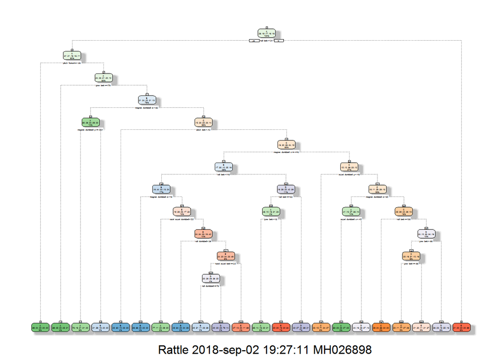

```r
#Decision Tree
set.seed(12345)
modFitDT <- rpart(classe ~ ., data = training, method="class", control = rpart.control(method = "cv", number = 10))
fancyRpartPlot(modFitDT)
```

```r
#Predicting
set.seed(12345)
prediction <- predict(modFitDT, testing, type = "class")
confMatDecTree <-confusionMatrix(prediction, testing$classe)
confMatDecTree
```

```
## Confusion Matrix and Statistics
##
##           Reference
## Prediction    A    B    C    D    E
##          A 1420  174   49   49   20
##          B   24  683   65   37   61
##          C   35   98  651   44   44
##          D  169  115  229  771  150
##          E   26   69   32   63  807
##
## Overall Statistics
##
##                Accuracy : 0.7361
##                  95% CI : (0.7246, 0.7473)
##     No Information Rate : 0.2845
##     P-Value [Acc > NIR] : < 2.2e-16
##
##                   Kappa : 0.6667
##  Mcnemar's Test P-Value : < 2.2e-16
##
## Statistics by Class:
##
##                      Class: A Class: B Class: C Class: D Class: E
## Sensitivity            0.8483   0.5996   0.6345   0.7998   0.7458
## Specificity            0.9307   0.9606   0.9545   0.8653   0.9604
## Pos Pred Value         0.8294   0.7851   0.7466   0.5377   0.8094
## Neg Pred Value         0.9391   0.9091   0.9252   0.9566   0.9437
## Prevalence             0.2845   0.1935   0.1743   0.1638   0.1839
## Detection Rate         0.2413   0.1161   0.1106   0.1310   0.1371
## Detection Prevalence   0.2909   0.1478   0.1482   0.2437   0.1694
## Balanced Accuracy      0.8895   0.7801   0.7945   0.8325   0.8531
```

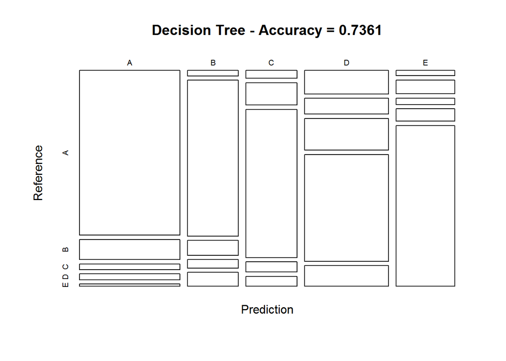

```r
DecTreeAccurancy <- round(confMatDecTree$overall['Accuracy'], 4)

# plot matrix results
plot(confMatDecTree$table, col = confMatDecTree$byClass,
     main = paste("Decision Tree - Accuracy =",DecTreeAccurancy))
```

# Random Forest

```r
# model fit
set.seed(301)
controlRF <- trainControl(method="cv", number=3, verboseIter=FALSE)
modFitRandForest <- train(classe ~ ., data=training, method="rf",
                          trControl=controlRF)
modFitRandForest$finalModel
```

```
##
## Call:
##  randomForest(x = x, y = y, mtry = param$mtry)
##                Type of random forest: classification
##                      Number of trees: 500
## No. of variables tried at each split: 27
##
##         OOB estimate of  error rate: 0.78%
## Confusion matrix:
##      A    B    C    D    E class.error
## A 3902    1    2    0    1 0.001024066
## B   23 2627    8    0    0 0.011662904
## C    0   17 2370    9    0 0.010851419
## D    0    1   30 2218    3 0.015097691
## E    0    1    3    8 2513 0.004752475
```

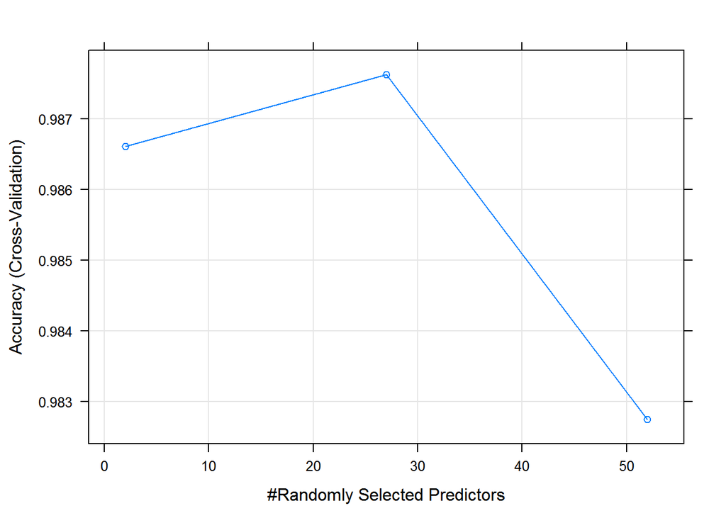

```r
plot(modFitRandForest)
```

```r
# prediction on Test dataset
predictRandForest <- predict(modFitRandForest, newdata=testing)
confMatRandForest <- confusionMatrix(predictRandForest, testing$classe)
confMatRandForest
```

```
## Confusion Matrix and Statistics
##
##           Reference
## Prediction    A    B    C    D    E
##          A 1672   13    0    0    0
##          B    2 1122   10    0    0
##          C    0    4 1014    8    1
##          D    0    0    2  956    2
##          E    0    0    0    0 1079
##
## Overall Statistics
##
##                Accuracy : 0.9929
##                  95% CI : (0.9904, 0.9949)
##     No Information Rate : 0.2845
##     P-Value [Acc > NIR] : < 2.2e-16
##
##                   Kappa : 0.991
##  Mcnemar's Test P-Value : NA
##
## Statistics by Class:
##
##                      Class: A Class: B Class: C Class: D Class: E
## Sensitivity            0.9988   0.9851   0.9883   0.9917   0.9972
## Specificity            0.9969   0.9975   0.9973   0.9992   1.0000
## Pos Pred Value         0.9923   0.9894   0.9873   0.9958   1.0000
## Neg Pred Value         0.9995   0.9964   0.9975   0.9984   0.9994
## Prevalence             0.2845   0.1935   0.1743   0.1638   0.1839
## Detection Rate         0.2841   0.1907   0.1723   0.1624   0.1833
## Detection Prevalence   0.2863   0.1927   0.1745   0.1631   0.1833
## Balanced Accuracy      0.9979   0.9913   0.9928   0.9954   0.9986
```

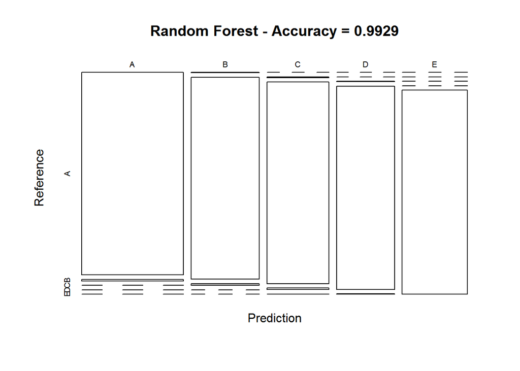

```r
RandomForestAccuracy <- round(confMatRandForest$overall['Accuracy'], 4)

#plot matrix results
plot(confMatRandForest$table, col = confMatRandForest$byClass,
     main = paste("Random Forest - Accuracy =",RandomForestAccuracy))
```

# GBM Generalized Boosted Model

```r
# model fit
set.seed(301)
controlGBM <- trainControl(method = "repeatedcv", number = 5, repeats = 1)
modFitGBM  <- train(classe ~ ., data=training, method = "gbm",
                    trControl = controlGBM, verbose = FALSE)

modFitGBM$finalModel
```

```
## A gradient boosted model with multinomial loss function.
## 150 iterations were performed.
## There were 52 predictors of which 46 had non-zero influence.
```

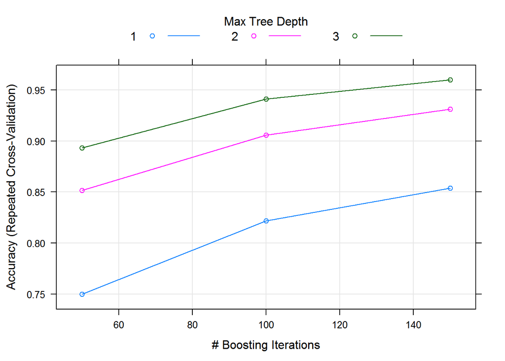

```r
plot(modFitGBM)
```

```r
# prediction on Test dataset
predictGBM <- predict(modFitGBM, newdata=testing)
confMatGBM <- confusionMatrix(predictGBM, testing$classe)
confMatGBM
```

```
## Confusion Matrix and Statistics
##
##           Reference
## Prediction    A    B    C    D    E
##          A 1648   44    0    1    1
##          B   17 1072   33    4   10
##          C    6   21  979   26    4
##          D    3    2   13  931   16
##          E    0    0    1    2 1051
##
## Overall Statistics
##
##                Accuracy : 0.9653
##                  95% CI : (0.9603, 0.9699)
##     No Information Rate : 0.2845
##     P-Value [Acc > NIR] : < 2.2e-16
##
##                   Kappa : 0.9561
##  Mcnemar's Test P-Value : 2.344e-07
##
## Statistics by Class:
##
##                      Class: A Class: B Class: C Class: D Class: E
## Sensitivity            0.9845   0.9412   0.9542   0.9658   0.9713
## Specificity            0.9891   0.9865   0.9883   0.9931   0.9994
## Pos Pred Value         0.9728   0.9437   0.9450   0.9648   0.9972
## Neg Pred Value         0.9938   0.9859   0.9903   0.9933   0.9936
## Prevalence             0.2845   0.1935   0.1743   0.1638   0.1839
## Detection Rate         0.2800   0.1822   0.1664   0.1582   0.1786
## Detection Prevalence   0.2879   0.1930   0.1760   0.1640   0.1791
## Balanced Accuracy      0.9868   0.9638   0.9712   0.9794   0.9854
```

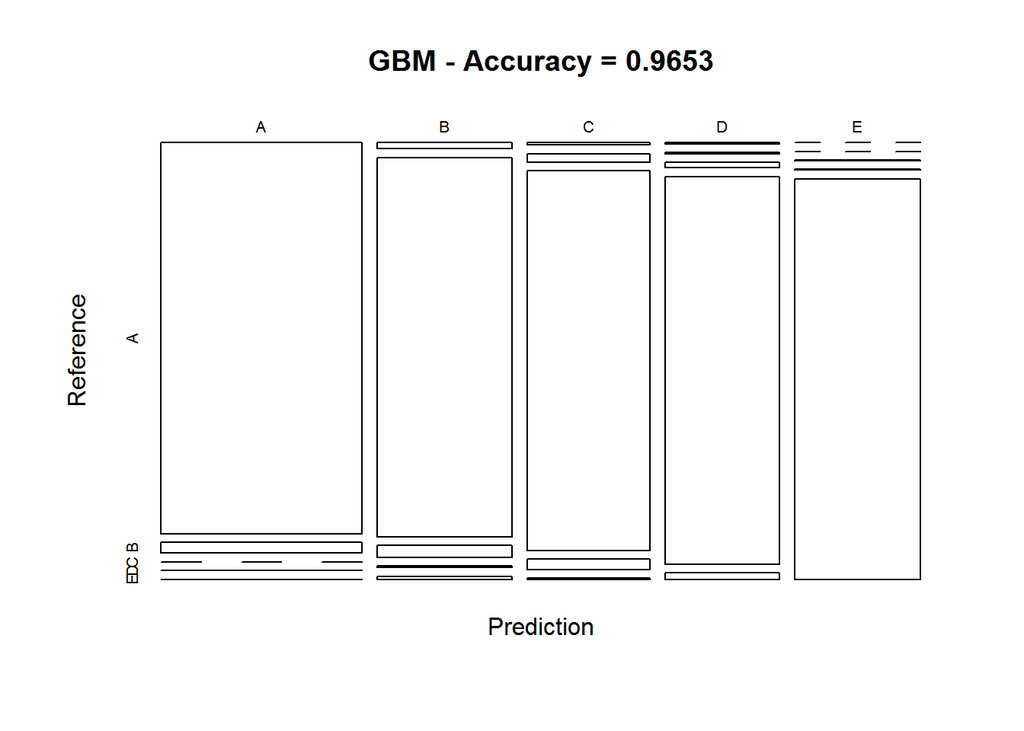

```r
GBMAccuracy <- round(confMatGBM$overall['Accuracy'], 4)
# plot matrix results
plot(confMatGBM$table, col = confMatGBM$byClass,
     main = paste("GBM - Accuracy =", GBMAccuracy))
```

# PREDICTING MODEL AND RESULTS

The accuracy of the 3 regression modeling methods above are:

```r
paste0("Random Forest : ",round(confMatRandForest$overall['Accuracy'], 4)," Decision Tree : ",DecTreeAccurancy," GBM : ",GBMAccuracy," .Based on this results, the Random Forest model will be applied to predict the 20 quiz results (testing dataset) as shown below.")
```

```
## [1] "Random Forest : 0.9929 Decision Tree : 0.7361 GBM : 0.9653 .Based on this results, the Random Forest model will be applied to predict the 20 quiz results (testing dataset) as shown below."
```

```r
predictTEST <- predict(modFitRandForest, newdata=TestSet)
predictTEST
```

```
##  [1] B A B A A E D B A A B C B A E E A B B B
## Levels: A B C D E
```